# When can an LLM label count as a sociological measure?

Session 2 · Annotation and measurement

Christopher Barrie · NYU Sociology

2026-09-09

## Today we will build one variable from twelve comments

“I want lower rents, but I cannot support the proposal unless the affordability rules become much stronger.”

**Research question**

What share of speakers explicitly supports adopting the rezoning proposal as written?

**What we need**

One stance label for each comment, plus evidence that those labels measure what we intend.

## The label depends on the question we are asking

I want lower rents, but I cannot support the proposal unless the affordability rules become much stronger.

| If we ask… | The relevant label is… |
| --- | --- |
| Does this speaker support adopting the proposal as written? | **UNCLEAR** — support is conditional on changing it. |
| Is this speaker open to policies intended to reduce rents? | **OPEN** — the opening clause supplies evidence. |

The text has not changed. The construct has.

## Sociologists have long turned written accounts into variables

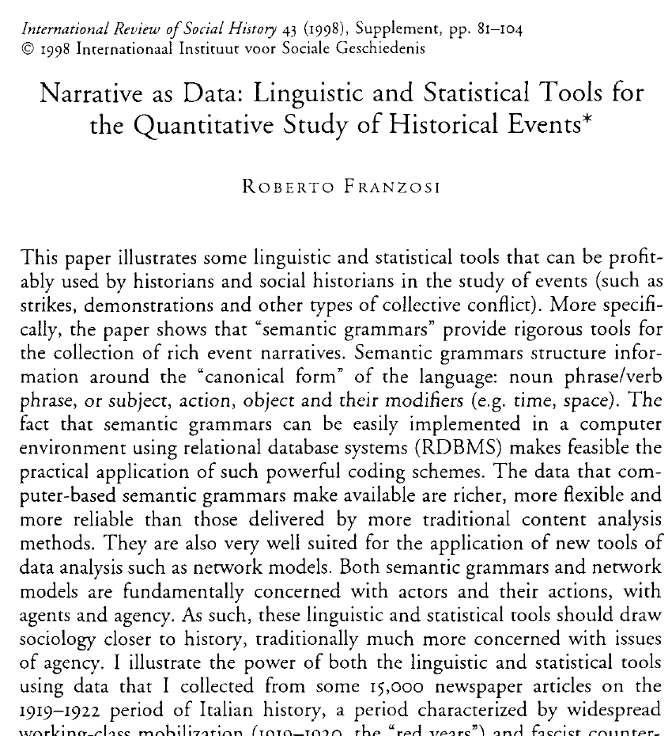

**Material:** newspaper reports of strikes, demonstrations and other collective conflict.

**Task:** record actors, actions, objects, time and place from narrative accounts.

**Purpose:** analyse historical processes without reducing stories to word counts alone.

Franzosi, R. (1998). “Narrative as Data: Linguistic and Statistical Tools for the Quantitative Study of Historical Events.” *International Review of Social History* 43(S6):81–104. https://doi.org/10.1017/S002085900011510X.

## Franzosi used coding rules to recover relations among actors

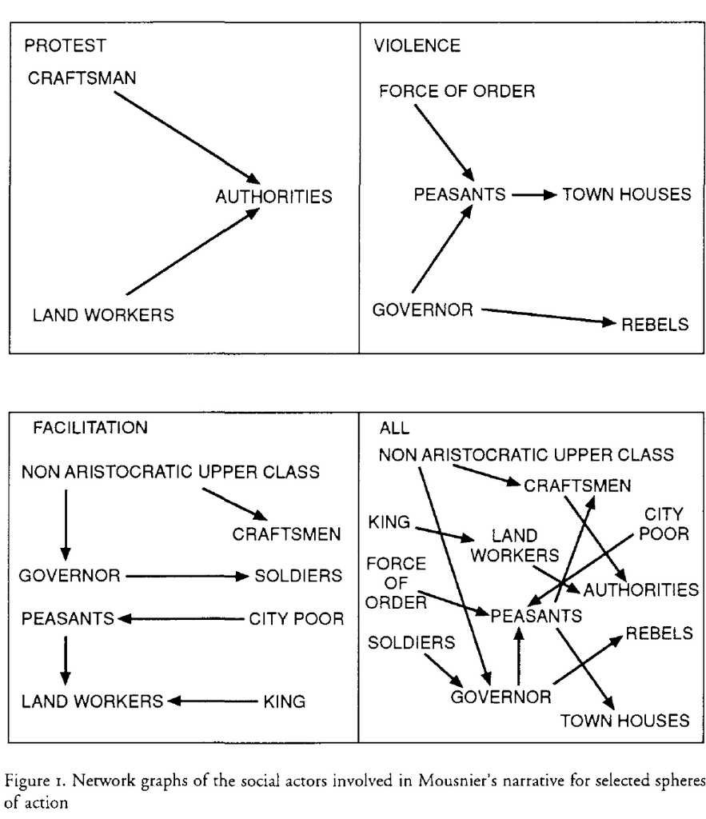

The published figure is an output of the coding process.

Names and actions in narrative sources were represented as actors and directed relations.

The analytic object—a network—depended on earlier decisions about what to record and how to group actors.

Franzosi (1998), Figure 1.

## A codebook links a sociological idea to a repeatable decision

**Construct**Explicit support for adopting the proposal as written

**Unit**One public comment from one speaker

**Allowed values**SUPPORT · OPPOSE · UNCLEAR

**Boundary rule**Conditional approval is UNCLEAR unless the speaker also endorses the current proposal

**Evidence**Save the words that determine the decision

A construct is the concept we want to measure. The codebook states how evidence in a text becomes a recorded value.

## Human coders apply the same rules to many cases

**Codebook excerpt**

Count SUPPORT only when the speaker endorses the proposal in its current form.

**Comment 03**

“I want lower rents, but I cannot support the proposal unless…”

SUPPORTOPPOSEUNCLEAR

Training, duplicate coding and adjudication make disagreements visible. They do not remove judgment from the task.

## Crowdworker platforms made coding easier to distribute

[figure not shown]

An MTurk Human Intelligence Task

[figure not shown]

A Prolific study setup screen

Researchers could send the same instructions and cases to many paid workers. Recruitment, pay, worker selection and quality control became part of the research design.

Interface images: Cordite Poetry Review, “Mechanical Turk Essay”; Cowen (2017), Prolific researcher walkthrough.

## Aggregated crowd judgments could match expert coding

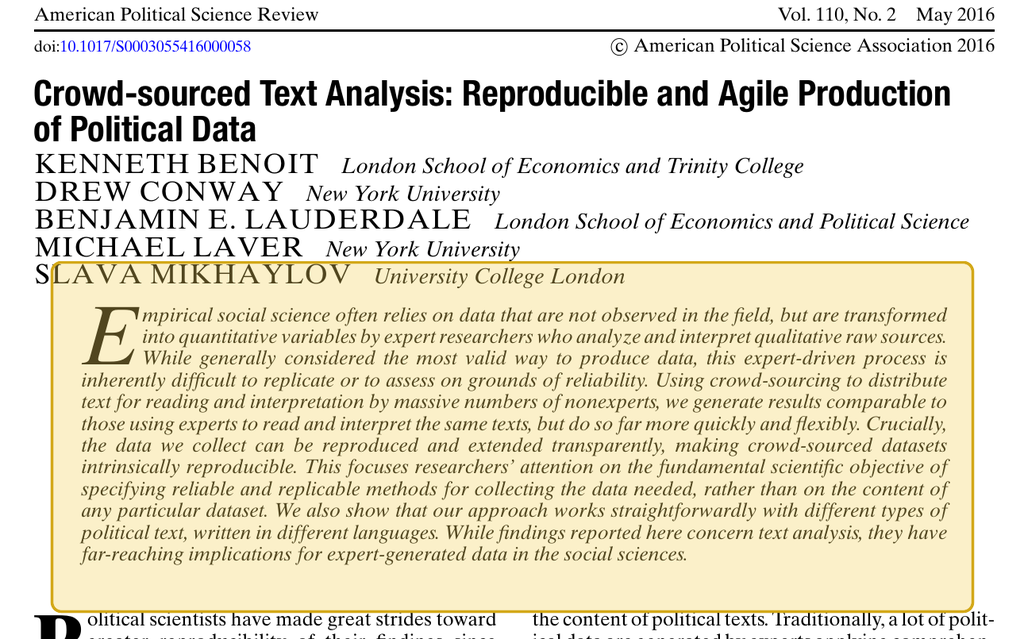

Benoit and colleagues divided text coding into small tasks completed by many nonexpert workers.

After aggregating their judgments, the results were comparable to expert coding but could be produced more quickly and flexibly.

**Researchers no longer had to depend on a small pool of experts or trained research assistants for every evaluation.**

Benoit, K., D. Conway, B. E. Lauderdale, M. Laver, and S. Mikhaylov. (2016). “Crowd-sourced Text Analysis: Reproducible and Agile Production of Political Data.” *American Political Science Review* 110(2):278–295. https://doi.org/10.1017/S0003055416000058.

## Crowdsourcing changes the workforce, not the coding question

| The researcher still decides | The platform adds | The study must report |
| --- | --- | --- |
| construct, unit and categories | access to paid workers | who was eligible to code |
| instructions and examples | parallel task distribution | pay, training and exclusions |
| how disagreement is handled | worker and task metadata | agreement and adjudication |

**For our comment:** each worker would still need a rule for conditional support. More workers cannot repair an undefined category.

See Wazny (2020), “Enhancing Big Data in the Social Sciences with Crowdsourcing,” *PLOS ONE* 15(6):e0233154.

## Supervised classifiers learned from the labels people produced

**Human-labelled examples**

```
01  SUPPORT
02  OPPOSE
03  UNCLEAR
...
```

**Fitted classifier**

The program learns patterns that distinguish the recorded categories.

**Predictions on new texts**

```
101  SUPPORT
102  UNCLEAR
103  OPPOSE
```

The training labels are the model’s examples of the construct. Errors or ambiguities in those labels travel into later predictions.

## An LLM can apply the written rules without task-specific training

**Input**

Research task Code stance toward adopting this proposal.

Codebook SUPPORT, OPPOSE or UNCLEAR; conditional approval is UNCLEAR.

Comment “I want lower rents, but I cannot support…”

**Returned record**

```
{
  "label": "UNCLEAR",
  "evidence": "cannot support ... unless",
  "reason": "support is conditional"
}
```

This is the specific use of an LLM in today’s class: one text enters; one proposed label and its supporting evidence come back.

## Our target is explicit support for the current proposal

**Unit**one comment

**Construct**stance toward adoption as written

**Values**SUPPORT · OPPOSE · UNCLEAR

**Quantity**share of comments coded SUPPORT

I want lower rents, but I cannot support the proposal unless the affordability rules become much stronger.

The red clause governs the stance label. The blue clause is relevant to a different question about policy goals.

## The codebook resolves the difficult cases before model selection

| Label | Use it when… | Example |
| --- | --- | --- |
| **SUPPORT** | the speaker endorses adopting the proposal in its current form | “The council should pass this plan.” |
| **OPPOSE** | the speaker rejects adopting it | “I oppose this proposal.” |
| **UNCLEAR** | there is no stance, mixed evidence or conditional approval only | “I could support it if the affordability rule changes.” |

These definitions are instructor-created for the synthetic exercise. They are not claimed to be the only defensible way to study housing comments.

## The prompt turns those decisions into a request

**Task**Classify the speaker’s stance toward adopting the proposal as written.

**Rules**Use SUPPORT, OPPOSE or UNCLEAR. Conditional approval alone is UNCLEAR.

**Evidence**Return the shortest phrase that determines the label.

**Format**Return JSON with `label`, `evidence` and `reason`.

**Current case**“I want lower rents, but I cannot support the proposal unless…”

The model receives all five parts together. The output format makes the response easier to inspect and store.

## The exercise uses transparent toy data

| Object | What it contains | Who made it |
| --- | --- | --- |
| 12 comments | short statements about one fictional rezoning proposal | instructor-authored |
| reference labels | labels produced from the displayed codebook | instructor-authored |
| model outputs | twelve illustrative JSON responses, including two deliberate errors | instructor-authored |
| prompt variants | three reasonable formulations and their illustrative labels | instructor-authored |

Nothing here estimates opinion in a real city. The small dataset lets us inspect every decision and every error.

## Two conditional comments account for both errors

**Comment 03**

“I want lower rents, but I cannot support the proposal unless…”

Reference: UNCLEAR · Model: SUPPORT

**Comment 11**

“I could accept additional housing if the city first guarantees…”

Reference: UNCLEAR · Model: SUPPORT

**Reference labels**4 of 12 SUPPORT**33%**

**Model labels**6 of 12 SUPPORT**50%**

The model treats favourable language as current support and overlooks the condition that qualifies it.

## We now need evidence about three parts of the measure

**Definition**

Do the categories and boundary rule represent explicit support?

**Application**

Do reasonable prompts and independent coders apply the rule consistently?

**Use**

Do the remaining errors change the quantity or comparison we want to report?

Every part will be evaluated using the same twelve comments and the same support estimate.

## Stuhler and colleagues make the annotation task concrete

[figure not shown]

**Material:** about 80,000 *New York Times* obituaries published from 1980 to March 2024.

**Task:** extract twelve biographical variables, including age, military service, education, religion and occupation.

**Comparison:** open-source Llama models versus manually coded test cases.

Stuhler, O., C. Dang Ton, and E. Ollion. (2025). “From Codebooks to Promptbooks: Extracting Information from Text with Generative Large Language Models.” *Sociological Methods & Research* 54(3):794–848. https://doi.org/10.1177/00491241251336794.

## Information extraction fills named fields from unstructured text

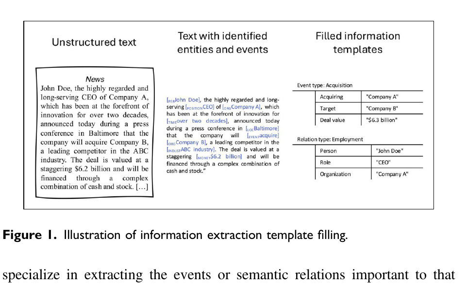

The output fields are chosen before the document is processed. In our exercise, the field is `stance` and its permitted values come from the codebook.

Stuhler, Dang Ton, and Ollion (2025), Figure 1.

## The promptbook adds instructions written for the model

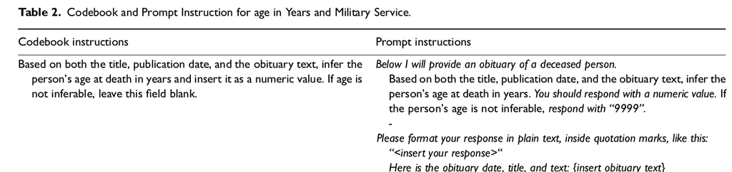

The prompt repeats the substantive rule.It adds the input placeholder.It specifies what to return when age is missing.It specifies the response format.

Stuhler, Dang Ton, and Ollion (2025), Table 2, age-in-years row.

## Different variables require different kinds of reading

| Variable | What must be found or inferred? | Why it may fail |
| --- | --- | --- |
| Age | an explicit number, usually near the beginning | unusual title or missing date |
| Military service | a sparse fact anywhere in the obituary | passing references or advisory roles |
| Education | institutions attended and the highest level completed | workplaces can be mistaken for attendance |
| Religion | explicit affiliation without imputing from associations | the model may supply a plausible but unsupported answer |

Stuhler, Dang Ton, and Ollion (2025), Table 1 and pp. 825–827.

## Performance differs across tasks and model sizes

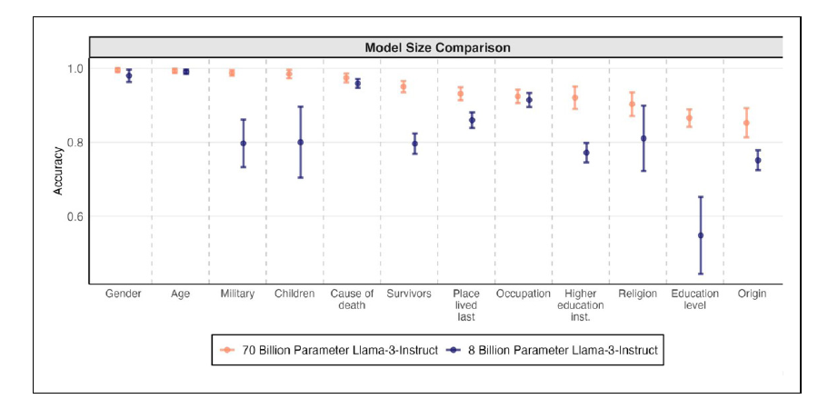

**Read across the x-axis:** the 70B model performs very well on explicit facts, while accuracy is lower for variables requiring more contextual inference. The 8B model falls much further on education level.

Stuhler, Dang Ton, and Ollion (2025), Figure 2. Orange: Llama 3 70B Instruct; blue: Llama 3 8B Instruct.

## Our boundary rule also asks the model to use context

**Easy lexical cue**

“I support the proposal.”

SUPPORT

**Context changes the decision**

“I support more housing, but not this proposal.”

OPPOSE

**Condition changes the decision**

“I could support it if the plan changes.”

UNCLEAR

Finding positive words is not the task. The label depends on what those words are attached to and whether support is current or conditional.

## Three reasonable prompts disagree on the conditional cases

| Comment | Direct instruction | Explicit boundary rule | Question form |
| --- | --- | --- | --- |
| 01 · clear support | SUPPORT | SUPPORT | SUPPORT |
| 03 · cannot support unless… | **SUPPORT** | UNCLEAR | UNCLEAR |
| 04 · clear opposition | OPPOSE | OPPOSE | OPPOSE |
| 11 · could accept if… | **SUPPORT** | UNCLEAR | **SUPPORT** |

The displayed outputs are synthetic. The disagreement is deliberately concentrated in the two boundary cases.

## Prompt stability compares reasonable versions of the same instruction

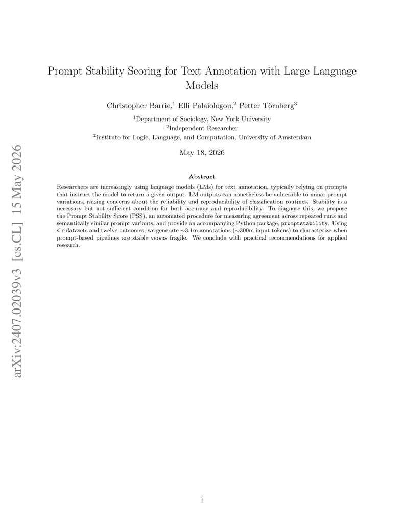

**Intra-prompt stability:** repeat the same prompt on the same texts.

**Inter-prompt stability:** use substantively equivalent formulations on the same texts.

The paper adapts coder-reliability ideas to model-generated annotations.

Barrie, C., E. Palaiologou, and P. Törnberg. (2024). “Prompt Stability Scoring for Text Annotation with Large Language Models.” arXiv:2407.02039. https://doi.org/10.48550/arXiv.2407.02039.

## Repetition and rewording diagnose different problems

**Repeat the direct prompt three times**

```
03  SUPPORT
03  SUPPORT
03  UNCLEAR
```

Sampling or service variation changes the label.

**Use three equivalent formulations once**

```
03  SUPPORT
03  UNCLEAR
03  UNCLEAR
```

The wording of the instrument changes the label.

Both examples use the same comment and the same intended construct.

## Prompt sensitivity varies across annotation tasks

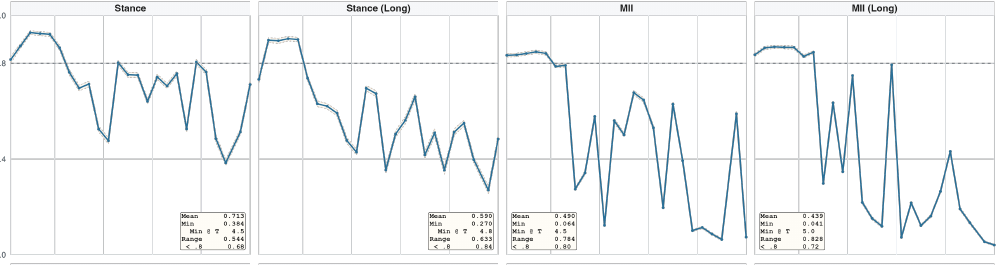

The same prompting strategy can be stable for one dataset and outcome but fragile for another. Stability must be checked for the actual task.

Barrie, Palaiologou, and Törnberg (2024), selected panels from Figure 2.

## The disagreement table tells us which rule needs attention

**Comment 03**

Direct: SUPPORT

Boundary rule: UNCLEAR

Question form: UNCLEAR

### What to inspect

Does the direct prompt leave “support” underspecified?

Does the question form still invite the model to focus on general openness?

Should conditional support receive its own category?

Instability is useful because it directs attention to a construct or instruction problem. A stability score alone cannot decide how the rule should change.

## A stable wrong label is still wrong for this codebook

**Three runs**

```
SUPPORT
SUPPORT
SUPPORT
```

**Reference rule**

Conditional approval only → UNCLEAR

**Conclusion**

The output is stable but disagrees with the intended boundary rule.

Reliability and agreement with an independent reference answer different questions.

## The two errors change the quantity we planned to report

**Record-level result****10 / 12**model labels match the reference

**Substantive quantity****50%**model-labelled support

**Reference quantity****33%**reference-labelled support

A classifier can look fairly accurate while moving the quantity the study was built to estimate.

## Egami and colleagues study what happens after annotation

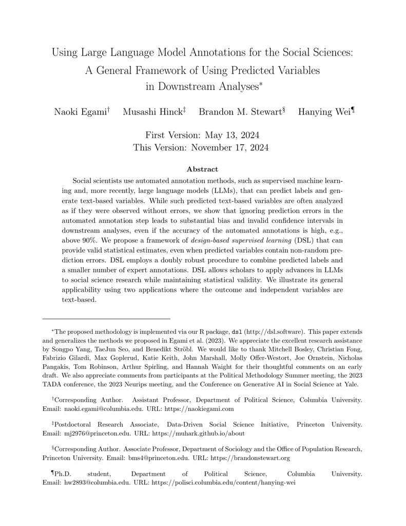

**Problem:** predicted labels are often analysed as if they were observed without error.

**Finding:** accuracy above 90% or 95% can still accompany biased estimates and confidence intervals with poor coverage.

**Design response:** combine large-scale predictions with an independently labelled probability sample.

Egami, N., M. Hinck, B. M. Stewart, and H. Wei. (2026). “Using Large Language Model Annotations for the Social Sciences: A General Framework of Using Predicted Variables in Downstream Analyses.” Working paper.

## Egami et al. add independent labels from a probability sample

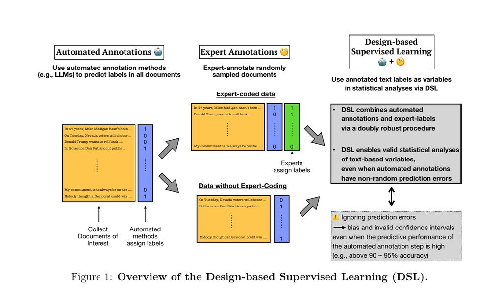

Automated labels cover the larger corpus.

Experts independently code a probability sample of documents.

The sampled labels are used to account for prediction error in the final estimate and its uncertainty.

Egami, Hinck, Stewart, and Wei (2026), Figure 1.